# Korean Poll 1987 : data

coop711

2019-09-08

## Data for Practice

한국 갤럽의 1987년 대선 여론조사 자료를 예제로 활용한다. 김용옥 선생이 ’나는 불교를 이렇게 본다’에서 인용한 한국갤럽의 발표자료는

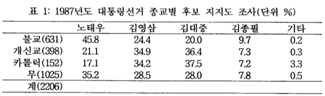

87대선 갤럽의 1987년 대선 여론조사

우선 이 자료를 입력하여 파일로 저장하자. 종교별 표본수를 먼저 벡터로 저장하고, 이름을 정한다.

```r
N_Religion <- c(631, 398, 152, 1025)
names(N_Religion) <- c("Buddhism", "Protestant", "Catholic", "None")
```

`table` 구조, 사실상 `matrix`로 읽어들인다.

```r
poll87 <- matrix(c(45.8, 21.1, 17.1, 35.2, 24.4, 34.9, 34.2, 28.5, 20.0, 36.4, 37.5, 28.0, 9.7, 7.3, 7.2, 7.8, 0.2, 0.3, 3.3, 0.5), ncol = 5)
poll87
```

```
##      [,1] [,2] [,3] [,4] [,5]
## [1,] 45.8 24.4 20.0  9.7  0.2
## [2,] 21.1 34.9 36.4  7.3  0.3
## [3,] 17.1 34.2 37.5  7.2  3.3
## [4,] 35.2 28.5 28.0  7.8  0.5
```

필요한 변수명을 넣는다.

```r
dimnames(poll87) <- list(Religion = names(N_Religion), Candidates = c("Roh", "YS", "DJ", "JP", "etc"))
poll87
```

```
##             Candidates
## Religion      Roh   YS   DJ  JP etc
##   Buddhism   45.8 24.4 20.0 9.7 0.2
##   Protestant 21.1 34.9 36.4 7.3 0.3
##   Catholic   17.1 34.2 37.5 7.2 3.3
##   None       35.2 28.5 28.0 7.8 0.5
```

```r
class(poll87)
```

```
## [1] "matrix"
```

```r
str(poll87)
```

```
##  num [1:4, 1:5] 45.8 21.1 17.1 35.2 24.4 34.9 34.2 28.5 20 36.4 ...
##  - attr(*, "dimnames")=List of 2
##   ..$ Religion  : chr [1:4] "Buddhism" "Protestant" "Catholic" "None"
##   ..$ Candidates: chr [1:5] "Roh" "YS" "DJ" "JP" ...
```

과연, 종교별 후보지지도의 합이 100%인지 `addmargins()`를 이용하여 확인. `margin = 2`로 행 단위 합.

```r
library(tidyverse)
poll87 %>%
  cbind(Sum = rowSums(.))
```

```
##             Roh   YS   DJ  JP etc   Sum
## Buddhism   45.8 24.4 20.0 9.7 0.2 100.1
## Protestant 21.1 34.9 36.4 7.3 0.3 100.0
## Catholic   17.1 34.2 37.5 7.2 3.3  99.3
## None       35.2 28.5 28.0 7.8 0.5 100.0
```

```r
addmargins(poll87, margin = 2)
```

```
##             Candidates
## Religion      Roh   YS   DJ  JP etc   Sum
##   Buddhism   45.8 24.4 20.0 9.7 0.2 100.1
##   Protestant 21.1 34.9 36.4 7.3 0.3 100.0
##   Catholic   17.1 34.2 37.5 7.2 3.3  99.3
##   None       35.2 28.5 28.0 7.8 0.5 100.0
```

카톨릭 표본의 소계가 잘 맞지 않는 것 확인. 종교별 표본수효 함께 출력.

```r
options(digits = 3)
cbind(poll87, N_Religion)
```

```
##             Roh   YS   DJ  JP etc N_Religion
## Buddhism   45.8 24.4 20.0 9.7 0.2        631
## Protestant 21.1 34.9 36.4 7.3 0.3        398
## Catholic   17.1 34.2 37.5 7.2 3.3        152
## None       35.2 28.5 28.0 7.8 0.5       1025
```

`N_Religion`의 이름을 표본 크기를 상징하는 `Size`로 교체

```r
cbind(poll87, Size = N_Religion)
```

```
##             Roh   YS   DJ  JP etc Size
## Buddhism   45.8 24.4 20.0 9.7 0.2  631
## Protestant 21.1 34.9 36.4 7.3 0.3  398
## Catholic   17.1 34.2 37.5 7.2 3.3  152
## None       35.2 28.5 28.0 7.8 0.5 1025
```

종교별 표본에서 각 후보의 지지자수를 계산한다. 사람의 수를 세는 만큼 소숫점 이하를 나오지 않도록 한다.

```r
options(digits = 0)
poll87_counts <- N_Religion * poll87 / 100
poll87_counts
```

```
##             Candidates
## Religion     Roh  YS  DJ JP etc
##   Buddhism   289 154 126 61   1
##   Protestant  84 139 145 29   1
##   Catholic    26  52  57 11   5
##   None       361 292 287 80   5
```

종교별 소계, 후보별 지지자 소계를 `addmargins()`를 이용하여 계산한다.

```r
poll87_counts %>%
  cbind(Sum = rowSums(.)) %>%
  rbind(Sum = colSums(.))
```

```
##            Roh  YS  DJ  JP etc  Sum
## Buddhism   289 154 126  61   1  632
## Protestant  84 139 145  29   1  398
## Catholic    26  52  57  11   5  151
## None       361 292 287  80   5 1025
## Sum        760 637 615 181  13 2206
```

```r
addmargins(poll87_counts)
```

```
##             Candidates
## Religion     Roh  YS  DJ  JP etc  Sum
##   Buddhism   289 154 126  61   1  632
##   Protestant  84 139 145  29   1  398
##   Catholic    26  52  57  11   5  151
##   None       361 292 287  80   5 1025
##   Sum        760 637 615 181  13 2206
```

반올림으로 인하여 불교와 카톨릭에서 1명씩의 차이가 나지만 전체 표본의 크기와는 잘 맞는 점을 확인.

후보별 지지율을 계산하기 위하여 `prop.table()`을 적용.

```r
options(digits = 2)
poll87_counts %>%
  prop.table
```

```
##             Candidates
## Religion       Roh    YS    DJ    JP     etc
##   Buddhism   0.131 0.070 0.057 0.028 0.00057
##   Protestant 0.038 0.063 0.066 0.013 0.00054
##   Catholic   0.012 0.024 0.026 0.005 0.00227
##   None       0.164 0.132 0.130 0.036 0.00232
```

```r
prop.table(poll87_counts)
```

```
##             Candidates
## Religion       Roh    YS    DJ    JP     etc
##   Buddhism   0.131 0.070 0.057 0.028 0.00057
##   Protestant 0.038 0.063 0.066 0.013 0.00054
##   Catholic   0.012 0.024 0.026 0.005 0.00227
##   None       0.164 0.132 0.130 0.036 0.00232
```

후보별 지지율 소계를 `addmargins()`를 이용하여 계산

```r
poll87_counts %>%
  prop.table %>%
  cbind(Sum = rowSums(.)) %>%
  rbind(Sum = colSums(.))
```

```
##              Roh    YS    DJ    JP     etc   Sum
## Buddhism   0.131 0.070 0.057 0.028 0.00057 0.286
## Protestant 0.038 0.063 0.066 0.013 0.00054 0.180
## Catholic   0.012 0.024 0.026 0.005 0.00227 0.068
## None       0.164 0.132 0.130 0.036 0.00232 0.465
## Sum        0.344 0.289 0.279 0.082 0.00571 1.000
```

```r
addmargins(prop.table(poll87_counts))
```

```
##             Candidates
## Religion       Roh    YS    DJ    JP     etc   Sum
##   Buddhism   0.131 0.070 0.057 0.028 0.00057 0.286
##   Protestant 0.038 0.063 0.066 0.013 0.00054 0.180
##   Catholic   0.012 0.024 0.026 0.005 0.00227 0.068
##   None       0.164 0.132 0.130 0.036 0.00232 0.465
##   Sum        0.344 0.289 0.279 0.082 0.00571 1.000
```

결론은 마지막 행에 있으므로,

```r
poll87_counts %>%
  prop.table %>%
  cbind(Sum = rowSums(.)) %>%
  rbind(Sum = colSums(.)) %>%
  `[`(5, 1:6) %>%
  `*`(100)
```

```
##    Roh     YS     DJ     JP    etc    Sum
##  34.45  28.88  27.89   8.21   0.57 100.00
```

```r
addmargins(prop.table(poll87_counts))[5, 1:6] * 100
```

```
##    Roh     YS     DJ     JP    etc    Sum
##  34.45  28.88  27.89   8.21   0.57 100.00
```

### Matrix to Table

`table` 구조로 강제 변환한다.

```r
poll87_tbl <- as.table(poll87_counts)
str(poll87_tbl)
```

```
##  'table' num [1:4, 1:5] 289 84 26 361 154 ...
##  - attr(*, "dimnames")=List of 2
##   ..$ Religion  : chr [1:4] "Buddhism" "Protestant" "Catholic" "None"
##   ..$ Candidates: chr [1:5] "Roh" "YS" "DJ" "JP" ...
```

### Tidy

```r
poll87_tbl <- poll87_counts %>%
  as_tibble %>%
  mutate(Religion = rownames(poll87_counts)) %>%
  gather(key = Candidates, value = Counts, -Religion) %>%
  mutate(Religion = factor(Religion, levels = rownames(poll87_counts)),
         Candidates = factor(Candidates, levels = colnames(poll87_counts)))
str(poll87_tbl)
```

```
## Classes 'tbl_df', 'tbl' and 'data.frame':    20 obs. of  3 variables:
##  $ Religion  : Factor w/ 4 levels "Buddhism","Protestant",..: 1 2 3 4 1 2 3 4 1 2 ...
##  $ Candidates: Factor w/ 5 levels "Roh","YS","DJ",..: 1 1 1 1 2 2 2 2 3 3 ...
##  $ Counts    : num  289 84 26 361 154 ...
```

### Save

```r
save.image(file = "poll87_data.RData")
```